# Depression Concept Creep, 2016-2026

2026-11-21

```r
## Set chunk options
knitr::opts_chunk$set(
  autodep = T, # Re-run cached chunks when objects they use from other chunks change
  cache.extra = tools::md5sum(c( # Re-run cached chunks when data or helper functions change
    list.files(here::here("Data"), recursive = T, full.names = T),
    here::here("Helper Functions", "Analysis Functions.R")
  ))
)


## Set seed
set.seed(87204)


## Load packages
library(here)
library(knitr)
library(kableExtra)
library(broom)
library(scales)
library(ggh4x)
library(mice)
library(marginaleffects)
library(tidyverse)
`%+%` <- paste0


## Load helper functions
source(here("Helper Functions", "Analysis Functions.R"))
source(here("Helper Functions", "DASS-21 Versus Norms.R"))


## Set global variables
study_period_labels <- c(
  "PIMH" = "First Study Period (2016-2019)",
  "PIH" = "Second Study Period (2019-2026)",
  "Combined" = "Combined"
)

severity_labels <- c(
  "5.5" = "Low (DASS = 5.5)",
  "8.5" = "Medium (DASS = 8.5)",
  "12"  = "High (DASS = 12)"
)

# Covariates used as moderators (3.1) and secondary predictors (3.2)
# Values: where numeric covariates are evaluated (factors: NULL, i.e., every level)
covariate_values <- list(
  age = c(20, 40, 60),
  race_recoded = NULL,
  gender = NULL,
  education = NULL,
  political_id_numeric = c(1, 4, 7), # Left, middle, right
  median_family_income = c(5, 10, 20), # In $10,000s
  dem_vote_share = c(.3, .5, .7),
  urban_rural = c(1, 4, 7, 10), # Metro, micro, town, rural
  provider_rate = c(100, 300, 500),
  referral_recoded = NULL
)

# Units for odds ratios of numeric covariates (e.g., age per 10 years); factors: 1
covariate_units <- c(
  age = 10, # 10 years
  race_recoded = 1,
  gender = 1,
  education = 1,
  political_id_numeric = 1,
  median_family_income = 1, # In $10,000s
  dem_vote_share = .1, # i.e., 10 percentage points
  urban_rural = 1,
  provider_rate = 100, # 100 per 100,000
  referral_recoded = 1
)

covariate_labels <- c(
  age = "Age",
  race_recoded = "Race/Ethnicity",
  gender = "Gender",
  education = "Education",
  political_id_numeric = "Political Ideology",
  median_family_income = "Median Family Income (ZIP Code)",
  dem_vote_share = "Democratic Vote Share (ZIP Code)",
  urban_rural = "Urban/Rural Area (RUCA Code)",
  provider_rate = "Mental Health Providers per 100,000 (County)",
  referral_recoded = "Reason for Visiting Website"
)

covariate_value_labels <- list(
  political_id_numeric = c("Strongly Liberal", "In the Middle", "Strongly Conservative"),
  median_family_income = c("$50,000", "$100,000", "$200,000"),
  dem_vote_share = c("30%", "50%", "70%"),
  urban_rural = c("Metropolitan Core (1)", "Micropolitan Core (4)", "Small Town Core (7)", "Rural (10)")
)


## Load data
# Non-imputed datasets ("_ni")
pimh_ni <- readRDS(here("Data", "PIMH - 2012-2019", "pimh_with_geo.rds"))
pih_ni <- readRDS(here("Data", "PIH - 2019-Current", "pih_with_geo.rds"))
all_ni <- bind_rows(pimh_ni, pih_ni)

# Completed ("_c")
pimh_c <- readRDS(here("Data", "PIMH - 2012-2019", "pimh_completed.rds"))
pih_c <- readRDS(here("Data", "PIH - 2019-Current", "pih_completed.rds"))
all_c <- readRDS(here("Data", "PIMH + PIH Combined", "all_completed.rds"))
```

# 1. Sample Description

## 1.1. Sample Description Table

```r
## Variables to report
# Categorical: reported as n (%), with %s excluding missing values
categorical_vars <- c(
  "Currently self-labels as having depression" = "dep_self_label_now",
  "Race/ethnicity" = "race_recoded",
  "Gender" = "gender",
  "Education" = "education",
  "Political ideology" = "political_id",
  "Urban/rural area (RUCA code)" = "urban_rural",
  "Reason for visiting website" = "referral_recoded"
)

# Continuous: reported as mean (SD), formatted to the given accuracy
continuous_vars <- tribble(
  ~var,                   ~label,                                              ~accuracy, ~prefix,
  "depression_sum",       "DASS-21 depression sum score",                     .01,       "",
  "age",                  "Age",                                              .1,        "",
  "dem_vote_share",       "Democratic vote share, ZIP code (%)",              .1,        "",
  "median_family_income", "Median family income, ZIP code (in 2024 dollars)", 1,         "$",
  "provider_rate",        "Mental health providers per 100,000, county",      .1,        ""
)

ruca_labels <- c("1-3: Metropolitan", "4-6: Micropolitan", "7-9: Small Town", "10: Rural")


## Prepare data: non-imputed, with a copy of all rows labeled "Combined"
table_data <- all_ni %>%
  bind_rows(mutate(all_ni, dataset = "Combined")) %>%
  mutate(
    dataset = factor(dataset, levels = names(study_period_labels)),
    dep_self_label_now = factor(dep_self_label_now, levels = c(TRUE, FALSE), labels = c("Yes", "No")),
    urban_rural = case_when(
      between(urban_rural, 1, 3) ~ ruca_labels[1],
      between(urban_rural, 4, 6) ~ ruca_labels[2],
      between(urban_rural, 7, 9) ~ ruca_labels[3],
      urban_rural == 10 ~ ruca_labels[4]
    ) %>%
      fct(levels = ruca_labels),
    dem_vote_share = dem_vote_share * 100, # Proportion to %
    median_family_income = median_family_income * 10000 # $10,000s to $
  )


## Summarize
categorical_summary <- map2(
  .x = categorical_vars,
  .y = names(categorical_vars),
  .f = ~ summarize_categorical(table_data, var = .x, label = .y)
) %>%
  bind_rows()

continuous_summary <- pmap(
  .l = continuous_vars,
  .f = ~ summarize_continuous(table_data, var = ..1, label = ..2, accuracy = ..3, prefix = ..4)
) %>%
  bind_rows()

sample_description <- bind_rows(categorical_summary, continuous_summary) %>%
  select(row, all_of(names(study_period_labels)), is_header)


## Print
column_ns <- table_data %>% count(dataset) %>% pull(n) %>% comma()

sample_description %>%
  select(-is_header) %>%
  mutate(across(everything(), ~ replace_na(.x, ""))) %>% # Blank cells in header rows
  kable(
    col.names = c("", study_period_labels %+% "\n(N = " %+% column_ns %+% ")"),
    align = c("l", "c", "c", "c"),
    escape = F
  ) %>%
  kable_styling(full_width = F) %>%
  pack_rows("Categorical variables, n (%)", 1, nrow(categorical_summary), indent = F) %>%
  pack_rows("Continuous variables, mean (SD)", nrow(categorical_summary) + 1, nrow(sample_description), indent = F) %>%
  row_spec(which(sample_description$is_header), bold = T) %>%
  add_indent(which(!sample_description$is_header & seq_len(nrow(sample_description)) <= nrow(categorical_summary)))
```

|  | First Study Period (2016-2019) (N = 22,469) | Second Study Period (2019-2026) (N = 37,109) | Combined (N = 59,578) |
| --- | --- | --- | --- |
| **Categorical variables, n (%)** |  |  |  |
| Currently self-labels as having depression |  |  |  |
| Yes | 7,010 (31.2%) | 11,779 (31.7%) | 18,789 (31.5%) |
| No | 15,459 (68.8%) | 25,330 (68.3%) | 40,789 (68.5%) |
| Race/ethnicity |  |  |  |
| White non-Hispanic | 12,820 (58.4%) | 19,813 (53.9%) | 32,633 (55.6%) |
| Black non-Hispanic | 2,023 (9.2%) | 3,561 (9.7%) | 5,584 (9.5%) |
| Asian non-Hispanic | 1,852 (8.4%) | 3,376 (9.2%) | 5,228 (8.9%) |
| Hispanic | 3,442 (15.7%) | 7,246 (19.7%) | 10,688 (18.2%) |
| Multiracial, Other or Unknown | 1,797 (8.2%) | 2,782 (7.6%) | 4,579 (7.8%) |
| Gender |  |  |  |
| (Cisgender) Man | 6,552 (29.3%) | 8,737 (23.7%) | 15,289 (25.8%) |
| (Cisgender) Woman | 15,801 (70.7%) | 27,231 (73.8%) | 43,032 (72.6%) |
| TGD | — | 940 (2.5%) | 940 (1.6%) |
| Education |  |  |  |
| High School or Less | 4,043 (18.3%) | 5,673 (20.8%) | 9,716 (19.6%) |
| Some College | 8,046 (36.3%) | 9,460 (34.6%) | 17,506 (35.4%) |
| Undergraduate Degree | 7,281 (32.9%) | 9,392 (34.4%) | 16,673 (33.7%) |
| Graduate Degree | 2,768 (12.5%) | 2,812 (10.3%) | 5,580 (11.3%) |
| Political ideology |  |  |  |
| Strongly Liberal | 5,168 (24.5%) | 4,016 (19.8%) | 9,184 (22.2%) |
| Moderately Liberal | 5,505 (26.1%) | 4,809 (23.7%) | 10,314 (24.9%) |
| Slightly Liberal | 1,964 (9.3%) | 2,049 (10.1%) | 4,013 (9.7%) |
| In the Middle | 5,017 (23.8%) | 5,557 (27.4%) | 10,574 (25.6%) |
| Slightly Conservative | 1,157 (5.5%) | 1,403 (6.9%) | 2,560 (6.2%) |
| Moderately Conservative | 1,553 (7.4%) | 1,763 (8.7%) | 3,316 (8.0%) |
| Strongly Conservative | 702 (3.3%) | 713 (3.5%) | 1,415 (3.4%) |
| Urban/rural area (RUCA code) |  |  |  |
| 1-3: Metropolitan | 17,086 (89.0%) | 28,505 (88.3%) | 45,591 (88.6%) |
| 4-6: Micropolitan | 1,252 (6.5%) | 2,237 (6.9%) | 3,489 (6.8%) |
| 7-9: Small Town | 260 (1.4%) | 560 (1.7%) | 820 (1.6%) |
| 10: Rural | 594 (3.1%) | 983 (3.0%) | 1,577 (3.1%) |
| Reason for visiting website |  |  |  |
| Assignment for school | — | 14,568 (76.5%) | 14,568 (76.5%) |
| Assignment for work | — | 2,041 (10.7%) | 2,041 (10.7%) |
| Other | — | 2,430 (12.8%) | 2,430 (12.8%) |
| **Continuous variables, mean (SD)** |  |  |  |
| DASS-21 depression sum score | 6.08 (5.09) | 6.13 (4.84) | 6.11 (4.93) |
| Age | 26.8 (11.1) | 26.3 (10.4) | 26.5 (10.6) |
| Democratic vote share, ZIP code (%) | 55.7 (20.0) | 55.5 (18.8) | 55.6 (19.3) |
| Median family income, ZIP code (in 2024 dollars) | $113,170 ($46,149) | $113,591 ($43,871) | $113,434 ($44,733) |
| Mental health providers per 100,000, county | 267.2 (165.3) | 342.0 (205.2) | 314.1 (194.7) |

## 1.2. Depression Symptom Severity Versus Norms

Normed density plots are constructed from reported studies’ summary statistics.

UK Norms (2005): Henry & Crawford (2005), Br J Clin Psychol 44:227-239

US Norms (2012): Sinclair et al. (2012), Eval Health Prof 35:259-279

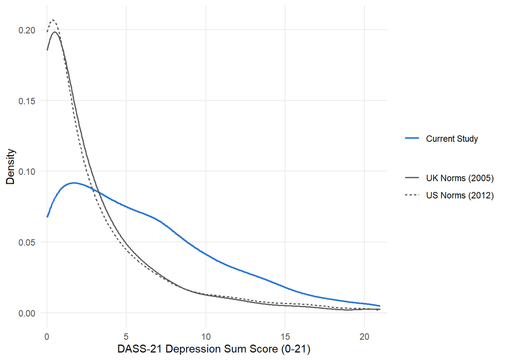

```
##                                 sample     n mean   sd median pct_zero
##                          Current Study 59578 6.11 4.93      5     10.0
##              UK 2005, Henry & Crawford  1794 2.83 3.87      1     34.0
##      UK 2009 enlarged, Crawford et al.  2928 3.18 4.16      2       NA
##        Australia 2011, Crawford et al.   497 2.57 3.86      1       NA
##  Australia 1995 manual, 42-item halved  2914 3.17 3.49     NA       NA
##               US 2012, Sinclair et al.   499 2.85 4.10      1     39.2
```

```r
dass21_dep_compare(all_ni, depression_sum)
```

This is a large sample that is disproportionately young, depressed, female, liberal, and metropolitan. Approx. 75% visited the website for school, but a significant number of participants visited for work or other reasons.

While participants are disproportionately depressed, the more important thing for our analyses (which condition on symptom severity) is that our sample covers the full range of depressive symptoms per the DASS-21. This is very much the case.

We will reckon with the uniqueness of our sample in our paper, but to head-off any concerns you might have at this stage: our findings are not moderated by reason for visiting website.

## 1.3. Trends in Outcomes

Trends in self-labeling and depressive symptom severity over time in the raw data; this is important context for our research questions, and it also allows us to examine the functional form of our models below.

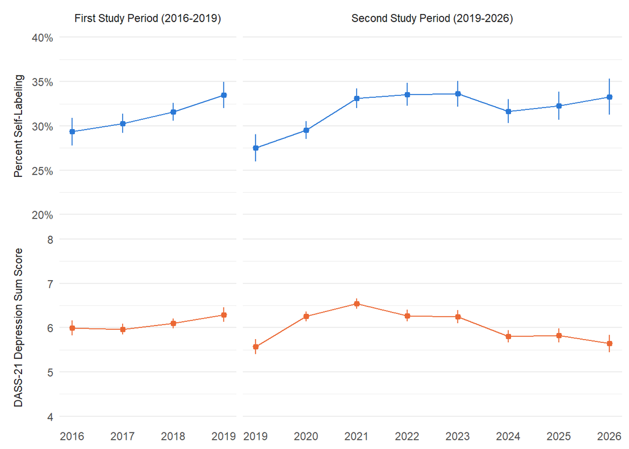

```r
## Observed trends in outcomes, by year (non-imputed data)
trends_by_year <- all_ni %>%
  mutate(
    study_period = fct(study_period_labels[dataset], levels = study_period_labels[c("PIMH", "PIH")]),
    `Percent Self-Labeling` = 100 * dep_self_label_now,
    `DASS-21 Depression Sum Score` = depression_sum
  ) %>%
  pivot_longer(
    c(`Percent Self-Labeling`, `DASS-21 Depression Sum Score`),
    names_to = "measure", values_to = "value"
  ) %>%
  summarize(
    estimate = mean(value, na.rm = T),
    se = sd(value, na.rm = T) / sqrt(sum(!is.na(value))),
    n = sum(!is.na(value)),
    .by = c(study_period, measure, year)
  ) %>%
  mutate(
    measure = fct(measure, levels = c("Percent Self-Labeling", "DASS-21 Depression Sum Score")),
    conf.low = estimate - qnorm(.975) * se,
    conf.high = estimate + qnorm(.975) * se
  )

trends_by_year %>%
  ggplot(aes(x = year, y = estimate, color = measure)) +
  geom_line(linewidth = .5) +
  geom_pointrange(aes(ymin = conf.low, ymax = conf.high), size = .3) +
  facet_grid(measure ~ study_period, scales = "free", space = "free_x", switch = "y") +
  facetted_pos_scales(y = list(
    measure == "Percent Self-Labeling" ~ scale_y_continuous(limits = c(20, 40), labels = label_percent(scale = 1)),
    measure == "DASS-21 Depression Sum Score" ~ scale_y_continuous(limits = c(4, 8))
  )) +
  scale_x_continuous(breaks = 2016:2026, expand = expansion(add = 0.25)) +
  scale_color_manual(
    values = c("Percent Self-Labeling" = "#2a78d6", "DASS-21 Depression Sum Score" = "#eb6834"),
    guide = "none"
  ) +
  labs(x = NULL, y = NULL) +
  theme_minimal() +
  theme(
    strip.placement = "outside",
    panel.grid.major.x = element_blank(),
    panel.grid.minor.x = element_blank()
  )
```

From these plots a few things are apparent:

- There is a significant discontinuity when data collection switched from PIMH to PIH; the sample got slightly less depressed, and self-labeled less (it makes sense that these things went down together). I would think this corresponds to shifts in sampling mechanisms across periods.
- Depression symptom severity in our sample matches nationwide trends in young adults; rising over time, peaking during the pandemic, and reducing afterwards.
- Depression self-labeling follows a similar trend. However, if you look closely, you can see the self-labeling trends are slightly tilted upwards, i.e., have a stronger slope; that is reflected in the modeling below.

These plots give us a good sense of general trends, but it’s hard to examine functional form from this. See `Examine Functional Form.Rmd` for plots and tests regarding the relationship between primary variables. To summarize: the relationship between time and self-labeling is linear, while the relationship symptom severity and self-labeling is broadly linear on the logit scale, but improved by the addition of quadratic and cubic terms. Results below are robust to this modeling choice, and robustness checks are available in `Robustness Checks/`.

# 2. Primary Analysis

The preregistered primary analysis model is `dep_self_label_now ~ depression_sum + decimal_year_centered + age + race_recoded + gender + education`.

Per the analyses in `Examine Functional Form.Rmd`, the relationship between time and self-labeling is linear, but the relationship between depressive symptom severity and self-labeling is polynomial (cubic). The functional form of the model is thus better represented by the function `dep_self_label_now ~ poly(depression_sum, 3, raw = TRUE) + decimal_year_centered + age + race_recoded + gender + education`.

For the primary analysis, we use the best-fit functions above. We report findings from simpler, preregistered models in `Robustness Checks/Preregistered Models.Rmd`. Findings are robust across operationalizations.

All analyses are run with complete cases on primary variables, and missing data on secondary variables is imputed with multiple imputation by chained equations (100 imputations). Findings are robust to imputation, as detailed in `Complete Cases.Rmd`.

## 2.1. Primary Regression Results

What follows are odds ratios, predicted probabilities, and risk ratios for each of the following models:

- PIMH data only
- PIH data only
- Combined dataset, with a `+ dataset` term to account for the study period differences observed above

You can skip to the visualizations in the following section to get a quick sense of the results. In the paper, we will primarily discuss findings in terms of risk ratios.

```r
# Save baseline model formulas
pimh_model_base <- "dep_self_label_now ~ poly(depression_sum, 3, raw = TRUE) + decimal_year_centered + age + race_recoded + gender + education"
pih_model_base <- "dep_self_label_now ~ poly(depression_sum, 3, raw = TRUE) + decimal_year_centered + age + race_recoded + gender + education"
all_model_base <- "dep_self_label_now ~ poly(depression_sum, 3, raw = TRUE) + decimal_year_centered + age + race_recoded + gender + education + dataset"

# Fit primary models, keeping results only
primary <- list(
  PIMH = summarize_fit(pimh_c, pimh_model_base, years = 2016:2019),
  PIH = summarize_fit(pih_c, pih_model_base, years = 2019:2026),
  Combined = summarize_fit(all_c, all_model_base, years = c(2016, 2026), plots = T)
)

# PIMH
show_table(odds_ratios(primary$PIMH$coefficients))
```

| term | estimate | p.value | conf.low | conf.high |
| --- | --- | --- | --- | --- |
| (Intercept) | 0.016 | 0.000 | 0.012 | 0.020 |
| poly(depression_sum, 3, raw = TRUE)1 | 1.957 | 0.000 | 1.844 | 2.077 |
| poly(depression_sum, 3, raw = TRUE)2 | 0.966 | 0.000 | 0.959 | 0.972 |
| poly(depression_sum, 3, raw = TRUE)3 | 1.001 | 0.000 | 1.001 | 1.001 |
| decimal_year_centered | 1.080 | 0.000 | 1.039 | 1.124 |
| age | 1.012 | 0.000 | 1.008 | 1.015 |
| race_recodedBlack non-Hispanic | 0.756 | 0.000 | 0.664 | 0.860 |
| race_recodedAsian non-Hispanic | 0.503 | 0.000 | 0.441 | 0.575 |
| race_recodedHispanic | 0.745 | 0.000 | 0.675 | 0.823 |
| race_recodedMultiracial, Other or Unknown | 0.872 | 0.032 | 0.770 | 0.988 |
| gender(Cisgender) Woman | 1.707 | 0.000 | 1.580 | 1.844 |
| educationSome College | 1.317 | 0.000 | 1.196 | 1.451 |
| educationUndergraduate Degree | 1.160 | 0.006 | 1.044 | 1.290 |
| educationGraduate Degree | 1.031 | 0.684 | 0.889 | 1.196 |

```r
show_table(primary$PIMH$predictions)
```

| depression_sum | decimal_year | estimate | conf.low | conf.high |
| --- | --- | --- | --- | --- |
| 5.5 | 2016 | 0.260 | 0.242 | 0.278 |
| 5.5 | 2017 | 0.275 | 0.262 | 0.287 |
| 5.5 | 2018 | 0.290 | 0.280 | 0.300 |
| 5.5 | 2019 | 0.306 | 0.293 | 0.318 |
| 8.5 | 2016 | 0.452 | 0.429 | 0.475 |
| 8.5 | 2017 | 0.471 | 0.456 | 0.486 |
| 8.5 | 2018 | 0.489 | 0.478 | 0.500 |
| 8.5 | 2019 | 0.508 | 0.494 | 0.522 |
| 12.0 | 2016 | 0.611 | 0.587 | 0.635 |
| 12.0 | 2017 | 0.629 | 0.612 | 0.646 |
| 12.0 | 2018 | 0.646 | 0.632 | 0.660 |
| 12.0 | 2019 | 0.663 | 0.648 | 0.678 |

```r
show_table(primary$PIMH$ratios)
```

| term | contrast | depression_sum | estimate | conf.low | conf.high | p.value |
| --- | --- | --- | --- | --- | --- | --- |
| decimal_year_centered | mean(+1) | 5.5 | 1.054 | 1.027 | 1.082 | 0 |
| decimal_year_centered | mean(+1) | 8.5 | 1.038 | 1.019 | 1.058 | 0 |
| decimal_year_centered | mean(+1) | 12.0 | 1.026 | 1.013 | 1.039 | 0 |

```r
# PIH
show_table(odds_ratios(primary$PIH$coefficients))
```

| term | estimate | p.value | conf.low | conf.high |
| --- | --- | --- | --- | --- |
| (Intercept) | 0.011 | 0.000 | 0.009 | 0.012 |
| poly(depression_sum, 3, raw = TRUE)1 | 1.749 | 0.000 | 1.675 | 1.826 |
| poly(depression_sum, 3, raw = TRUE)2 | 0.973 | 0.000 | 0.968 | 0.979 |
| poly(depression_sum, 3, raw = TRUE)3 | 1.001 | 0.000 | 1.000 | 1.001 |
| decimal_year_centered | 1.044 | 0.000 | 1.030 | 1.057 |
| age | 1.025 | 0.000 | 1.021 | 1.028 |
| race_recodedBlack non-Hispanic | 0.899 | 0.022 | 0.820 | 0.985 |
| race_recodedAsian non-Hispanic | 0.434 | 0.000 | 0.393 | 0.479 |
| race_recodedHispanic | 0.726 | 0.000 | 0.678 | 0.777 |
| race_recodedMultiracial, Other or Unknown | 0.779 | 0.000 | 0.706 | 0.860 |
| gender(Cisgender) Woman | 2.036 | 0.000 | 1.907 | 2.172 |
| genderTGD | 3.545 | 0.000 | 3.024 | 4.154 |
| educationSome College | 1.352 | 0.000 | 1.248 | 1.466 |
| educationUndergraduate Degree | 1.271 | 0.000 | 1.166 | 1.387 |
| educationGraduate Degree | 1.006 | 0.925 | 0.883 | 1.147 |

```r
show_table(primary$PIH$predictions)
```

| depression_sum | decimal_year | estimate | conf.low | conf.high |
| --- | --- | --- | --- | --- |
| 5.5 | 2019 | 0.268 | 0.257 | 0.279 |
| 5.5 | 2020 | 0.276 | 0.266 | 0.285 |
| 5.5 | 2021 | 0.284 | 0.276 | 0.292 |
| 5.5 | 2022 | 0.293 | 0.285 | 0.300 |
| 5.5 | 2023 | 0.301 | 0.294 | 0.308 |
| 5.5 | 2024 | 0.310 | 0.301 | 0.318 |
| 5.5 | 2025 | 0.318 | 0.309 | 0.328 |
| 5.5 | 2026 | 0.327 | 0.315 | 0.339 |
| 8.5 | 2019 | 0.437 | 0.424 | 0.451 |
| 8.5 | 2020 | 0.447 | 0.436 | 0.458 |
| 8.5 | 2021 | 0.457 | 0.448 | 0.467 |
| 8.5 | 2022 | 0.467 | 0.459 | 0.476 |
| 8.5 | 2023 | 0.477 | 0.469 | 0.486 |
| 8.5 | 2024 | 0.488 | 0.478 | 0.497 |
| 8.5 | 2025 | 0.498 | 0.487 | 0.509 |
| 8.5 | 2026 | 0.508 | 0.494 | 0.521 |
| 12.0 | 2019 | 0.587 | 0.573 | 0.602 |
| 12.0 | 2020 | 0.597 | 0.584 | 0.610 |
| 12.0 | 2021 | 0.607 | 0.595 | 0.618 |
| 12.0 | 2022 | 0.616 | 0.606 | 0.627 |
| 12.0 | 2023 | 0.626 | 0.615 | 0.636 |
| 12.0 | 2024 | 0.635 | 0.624 | 0.646 |
| 12.0 | 2025 | 0.644 | 0.632 | 0.657 |
| 12.0 | 2026 | 0.654 | 0.639 | 0.668 |

```r
show_table(primary$PIH$ratios)
```

| term | contrast | depression_sum | estimate | conf.low | conf.high | p.value |
| --- | --- | --- | --- | --- | --- | --- |
| decimal_year_centered | mean(+1) | 5.5 | 1.029 | 1.020 | 1.038 | 0 |
| decimal_year_centered | mean(+1) | 8.5 | 1.021 | 1.015 | 1.028 | 0 |
| decimal_year_centered | mean(+1) | 12.0 | 1.015 | 1.011 | 1.020 | 0 |

```r
# Combined
show_table(odds_ratios(primary$Combined$coefficients))
```

| term | estimate | p.value | conf.low | conf.high |
| --- | --- | --- | --- | --- |
| (Intercept) | 0.011 | 0.000 | 0.010 | 0.013 |
| poly(depression_sum, 3, raw = TRUE)1 | 1.817 | 0.000 | 1.754 | 1.881 |
| poly(depression_sum, 3, raw = TRUE)2 | 0.971 | 0.000 | 0.967 | 0.975 |
| poly(depression_sum, 3, raw = TRUE)3 | 1.001 | 0.000 | 1.000 | 1.001 |
| decimal_year_centered | 1.050 | 0.000 | 1.037 | 1.063 |
| age | 1.019 | 0.000 | 1.017 | 1.022 |
| race_recodedBlack non-Hispanic | 0.850 | 0.000 | 0.789 | 0.916 |
| race_recodedAsian non-Hispanic | 0.457 | 0.000 | 0.422 | 0.494 |
| race_recodedHispanic | 0.730 | 0.000 | 0.690 | 0.772 |
| race_recodedMultiracial, Other or Unknown | 0.813 | 0.000 | 0.752 | 0.878 |
| gender(Cisgender) Woman | 1.892 | 0.000 | 1.800 | 1.988 |
| genderTGD | 3.231 | 0.000 | 2.765 | 3.777 |
| educationSome College | 1.341 | 0.000 | 1.260 | 1.428 |
| educationUndergraduate Degree | 1.238 | 0.000 | 1.157 | 1.325 |
| educationGraduate Degree | 1.023 | 0.651 | 0.927 | 1.128 |
| datasetPIMH | 1.266 | 0.000 | 1.182 | 1.357 |

```r
show_table(primary$Combined$predictions)
```

| depression_sum | decimal_year | estimate | conf.low | conf.high |
| --- | --- | --- | --- | --- |
| 5.5 | 2016 | 0.250 | 0.238 | 0.262 |
| 5.5 | 2026 | 0.347 | 0.332 | 0.363 |
| 8.5 | 2016 | 0.424 | 0.408 | 0.439 |
| 8.5 | 2026 | 0.539 | 0.522 | 0.555 |
| 12.0 | 2016 | 0.577 | 0.561 | 0.594 |
| 12.0 | 2026 | 0.685 | 0.669 | 0.700 |

```r
show_table(primary$Combined$ratios)
```

| term | contrast | depression_sum | estimate | conf.low | conf.high | p.value |
| --- | --- | --- | --- | --- | --- | --- |
| decimal_year_centered | mean(+1) | 5.5 | 1.033 | 1.025 | 1.042 | 0 |
| decimal_year_centered | mean(+1) | 8.5 | 1.024 | 1.018 | 1.030 | 0 |
| decimal_year_centered | mean(+1) | 12.0 | 1.017 | 1.013 | 1.021 | 0 |

## 2.2. Primary Regression Results, Visualized

For the sake of parsimony, and because results do not differ meaningfully between datasets, results will be visualized using the combined model.

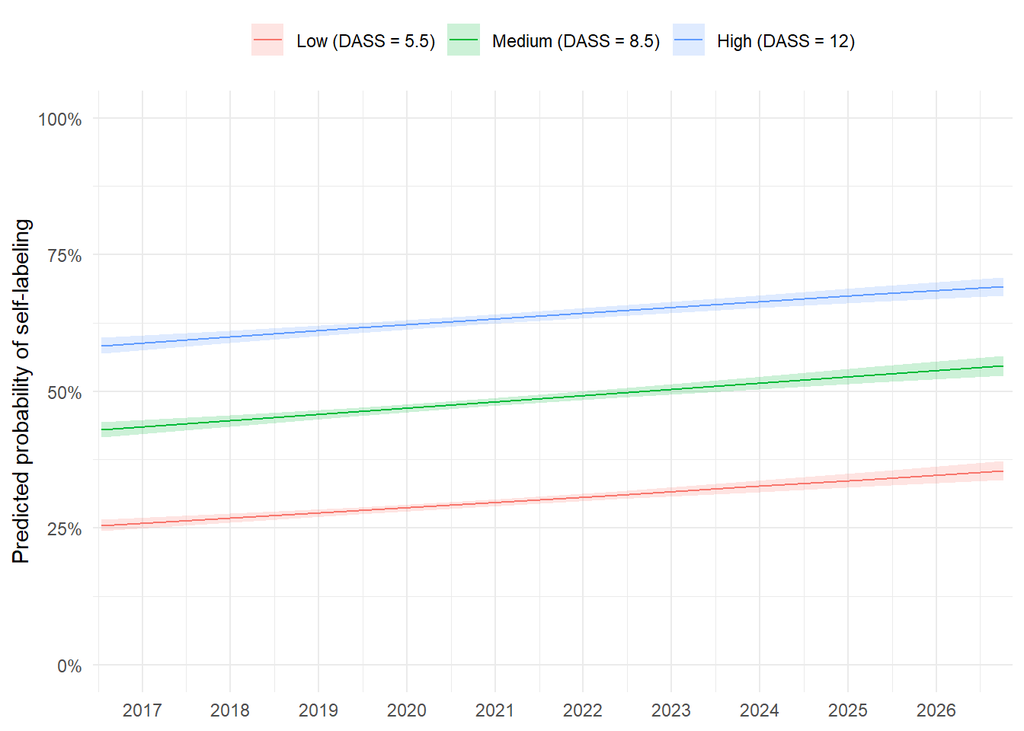

```r
plot_trend(primary$Combined$trend)
```

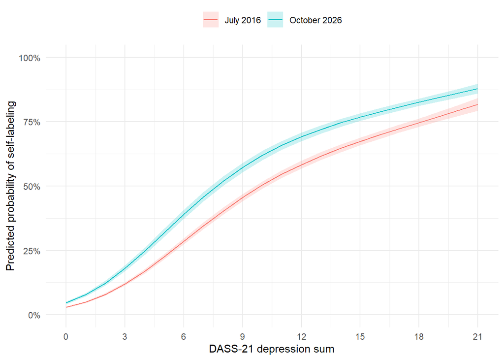

```r
plot_curve(primary$Combined$curve)
```

The first figure illustrates the linear effect of time on self-labeling, conditional on symptom severity. The second figure illustrates the change in the relationship between depressive symptom severity and self-labeling from the beginning to the end of the study. (These are the cubic logistic curves, although you can see that they do not differ dramatically from linear logistic curves.)

# 3. Secondary Analyses

## 3.1. Moderation of Primary Analyses

```r
# Each covariate's interaction with year is added to the primary model, in each dataset
# Combined data: the covariate's effect may also differ by study period (covariate:dataset), so moderation is not confounded with the change between study periods
# Reason for visiting was asked in PIH only; gender is tested in each dataset separately, not combined (TGD participants were identified in PIH only)

# Fit moderation models, keeping results only; plot data for the combined data only
moderation <- expand_grid(
  dataset = c("PIMH", "PIH", "Combined"),
  moderator = names(covariate_values)
) %>%
  filter(moderator != "referral_recoded" | dataset == "PIH", moderator != "gender" | dataset != "Combined") %>%
  mutate(
    data = list(PIMH = pimh_c, PIH = pih_c, Combined = all_c)[dataset],
    base = c(PIMH = pimh_model_base, PIH = pih_model_base, Combined = all_model_base)[dataset],
    base = if_else(dataset == "Combined", base %+% " + dataset:" %+% moderator, base),
    results = pmap(
      list(data, base, moderator, dataset),
      ~ fit_moderation(..1, ..2, ..3, covariate_values[[..3]], covariate_units[[..3]], plots = ..4 == "Combined")
    )
  ) %>%
  select(-data)

# Moderator x year odds ratios (per unit of numeric moderators), with Benjamini-Hochberg correction within each dataset
moderation %>%
  mutate(coefficients = map(results, "coefficients")) %>%
  select(dataset, coefficients) %>%
  unnest(coefficients) %>%
  mutate(p.adjusted = p.adjust(p.value, method = "BH"), .by = dataset) %>%
  show_table()
```

| dataset | moderator | unit | term | estimate | p.value | conf.low | conf.high | p.adjusted |
| --- | --- | --- | --- | --- | --- | --- | --- | --- |
| PIMH | age | 10.0 | decimal_year_centered:age | 0.997 | 0.855 | 0.961 | 1.033 | 0.980 |
| PIMH | race_recoded | 1.0 | decimal_year_centered:race_recodedBlack non-Hispanic | 1.079 | 0.328 | 0.927 | 1.255 | 0.887 |
| PIMH | race_recoded | 1.0 | decimal_year_centered:race_recodedAsian non-Hispanic | 1.101 | 0.212 | 0.946 | 1.281 | 0.887 |
| PIMH | race_recoded | 1.0 | decimal_year_centered:race_recodedHispanic | 0.999 | 0.980 | 0.888 | 1.123 | 0.980 |
| PIMH | race_recoded | 1.0 | decimal_year_centered:race_recodedMultiracial, Other or Unknown | 1.060 | 0.431 | 0.917 | 1.226 | 0.887 |
| PIMH | gender | 1.0 | decimal_year_centered:gender(Cisgender) Woman | 1.043 | 0.352 | 0.955 | 1.139 | 0.887 |
| PIMH | education | 1.0 | decimal_year_centered:educationSome College | 1.003 | 0.955 | 0.897 | 1.122 | 0.980 |
| PIMH | education | 1.0 | decimal_year_centered:educationUndergraduate Degree | 0.991 | 0.879 | 0.884 | 1.112 | 0.980 |
| PIMH | education | 1.0 | decimal_year_centered:educationGraduate Degree | 0.944 | 0.444 | 0.814 | 1.094 | 0.887 |
| PIMH | political_id_numeric | 1.0 | decimal_year_centered:political_id_numeric | 1.005 | 0.710 | 0.980 | 1.030 | 0.980 |
| PIMH | median_family_income | 1.0 | decimal_year_centered:median_family_income | 1.002 | 0.667 | 0.993 | 1.011 | 0.980 |
| PIMH | dem_vote_share | 0.1 | decimal_year_centered:dem_vote_share | 1.017 | 0.110 | 0.996 | 1.039 | 0.887 |
| PIMH | urban_rural | 1.0 | decimal_year_centered:urban_rural | 0.996 | 0.706 | 0.975 | 1.017 | 0.980 |
| PIMH | provider_rate | 100.0 | decimal_year_centered:provider_rate | 1.018 | 0.170 | 0.993 | 1.043 | 0.887 |
| PIH | age | 10.0 | decimal_year_centered:age | 1.013 | 0.042 | 1.000 | 1.026 | 0.717 |
| PIH | race_recoded | 1.0 | decimal_year_centered:race_recodedBlack non-Hispanic | 1.013 | 0.571 | 0.968 | 1.060 | 0.721 |
| PIH | race_recoded | 1.0 | decimal_year_centered:race_recodedAsian non-Hispanic | 1.024 | 0.355 | 0.974 | 1.077 | 0.721 |
| PIH | race_recoded | 1.0 | decimal_year_centered:race_recodedHispanic | 1.005 | 0.791 | 0.971 | 1.039 | 0.841 |
| PIH | race_recoded | 1.0 | decimal_year_centered:race_recodedMultiracial, Other or Unknown | 0.976 | 0.323 | 0.929 | 1.025 | 0.721 |
| PIH | gender | 1.0 | decimal_year_centered:gender(Cisgender) Woman | 1.009 | 0.581 | 0.976 | 1.044 | 0.721 |
| PIH | gender | 1.0 | decimal_year_centered:genderTGD | 1.042 | 0.328 | 0.960 | 1.130 | 0.721 |
| PIH | education | 1.0 | decimal_year_centered:educationSome College | 0.990 | 0.624 | 0.951 | 1.031 | 0.721 |
| PIH | education | 1.0 | decimal_year_centered:educationUndergraduate Degree | 1.025 | 0.227 | 0.985 | 1.066 | 0.721 |
| PIH | education | 1.0 | decimal_year_centered:educationGraduate Degree | 1.034 | 0.250 | 0.977 | 1.095 | 0.721 |
| PIH | political_id_numeric | 1.0 | decimal_year_centered:political_id_numeric | 0.997 | 0.514 | 0.988 | 1.006 | 0.721 |
| PIH | median_family_income | 1.0 | decimal_year_centered:median_family_income | 0.998 | 0.270 | 0.995 | 1.001 | 0.721 |
| PIH | dem_vote_share | 0.1 | decimal_year_centered:dem_vote_share | 0.998 | 0.636 | 0.991 | 1.006 | 0.721 |
| PIH | urban_rural | 1.0 | decimal_year_centered:urban_rural | 0.998 | 0.583 | 0.991 | 1.005 | 0.721 |
| PIH | provider_rate | 100.0 | decimal_year_centered:provider_rate | 0.995 | 0.100 | 0.988 | 1.001 | 0.721 |
| PIH | referral_recoded | 1.0 | decimal_year_centered:referral_recodedAssignment for work | 1.017 | 0.560 | 0.961 | 1.076 | 0.721 |
| PIH | referral_recoded | 1.0 | decimal_year_centered:referral_recodedOther | 0.999 | 0.975 | 0.942 | 1.060 | 0.975 |
| Combined | age | 10.0 | decimal_year_centered:age | 1.011 | 0.066 | 0.999 | 1.023 | 0.723 |
| Combined | race_recoded | 1.0 | decimal_year_centered:race_recodedBlack non-Hispanic | 1.022 | 0.334 | 0.978 | 1.068 | 0.723 |
| Combined | race_recoded | 1.0 | decimal_year_centered:race_recodedAsian non-Hispanic | 1.032 | 0.202 | 0.983 | 1.083 | 0.723 |
| Combined | race_recoded | 1.0 | decimal_year_centered:race_recodedHispanic | 1.006 | 0.741 | 0.973 | 1.039 | 0.803 |
| Combined | race_recoded | 1.0 | decimal_year_centered:race_recodedMultiracial, Other or Unknown | 0.985 | 0.530 | 0.940 | 1.032 | 0.775 |
| Combined | education | 1.0 | decimal_year_centered:educationSome College | 0.992 | 0.667 | 0.954 | 1.030 | 0.788 |
| Combined | education | 1.0 | decimal_year_centered:educationUndergraduate Degree | 1.023 | 0.243 | 0.985 | 1.062 | 0.723 |
| Combined | education | 1.0 | decimal_year_centered:educationGraduate Degree | 1.023 | 0.414 | 0.969 | 1.079 | 0.769 |
| Combined | political_id_numeric | 1.0 | decimal_year_centered:political_id_numeric | 0.998 | 0.596 | 0.990 | 1.006 | 0.775 |
| Combined | median_family_income | 1.0 | decimal_year_centered:median_family_income | 0.998 | 0.303 | 0.995 | 1.001 | 0.723 |
| Combined | dem_vote_share | 0.1 | decimal_year_centered:dem_vote_share | 1.000 | 0.908 | 0.994 | 1.007 | 0.908 |
| Combined | urban_rural | 1.0 | decimal_year_centered:urban_rural | 0.998 | 0.553 | 0.991 | 1.005 | 0.775 |
| Combined | provider_rate | 100.0 | decimal_year_centered:provider_rate | 0.995 | 0.149 | 0.989 | 1.002 | 0.723 |

## 3.2. Concept Breadth by Participant Characteristics

These tests use PIH data only, since (a) some characteristics were measured differently across study periods and (b) we aren’t interested in change over time, so using the most recent study period alone is sensible.

Odds ratios and risk ratios are provided in the tables below. Many are significant; you can look below to figures that illustrate these effects.

```r
# Baseline model for these tests
secondary_base <- "dep_self_label_now ~ poly(depression_sum, 3, raw = TRUE)"

# Fit each model, keeping results only (numeric covariates: risk ratio = highest vs. lowest value)
secondary <- imap(covariate_values, ~ fit_secondary(pih_c, secondary_base, .y, .x, covariate_units[[.y]]))

# Covariate odds ratios (per unit of numeric covariates), with Benjamini-Hochberg correction across all terms
map(secondary, "coefficients") %>%
  bind_rows() %>%
  mutate(p.adjusted = p.adjust(p.value, method = "BH")) %>%
  show_table()
```

| covariate | unit | term | estimate | p.value | conf.low | conf.high | p.adjusted |
| --- | --- | --- | --- | --- | --- | --- | --- |
| age | 10.0 | age | 1.292 | 0.000 | 1.260 | 1.325 | 0.000 |
| race_recoded | 1.0 | race_recodedBlack non-Hispanic | 0.917 | 0.058 | 0.838 | 1.003 | 0.061 |
| race_recoded | 1.0 | race_recodedAsian non-Hispanic | 0.386 | 0.000 | 0.350 | 0.425 | 0.000 |
| race_recoded | 1.0 | race_recodedHispanic | 0.691 | 0.000 | 0.647 | 0.738 | 0.000 |
| race_recoded | 1.0 | race_recodedMultiracial, Other or Unknown | 0.750 | 0.000 | 0.681 | 0.826 | 0.000 |
| gender | 1.0 | gender(Cisgender) Woman | 2.067 | 0.000 | 1.939 | 2.203 | 0.000 |
| gender | 1.0 | genderTGD | 3.451 | 0.000 | 2.951 | 4.036 | 0.000 |
| education | 1.0 | educationSome College | 1.569 | 0.000 | 1.452 | 1.695 | 0.000 |
| education | 1.0 | educationUndergraduate Degree | 1.672 | 0.000 | 1.545 | 1.810 | 0.000 |
| education | 1.0 | educationGraduate Degree | 1.673 | 0.000 | 1.498 | 1.869 | 0.000 |
| political_id_numeric | 1.0 | political_id_numeric | 0.907 | 0.000 | 0.891 | 0.923 | 0.000 |
| median_family_income | 1.0 | median_family_income | 0.984 | 0.000 | 0.978 | 0.990 | 0.000 |
| dem_vote_share | 0.1 | dem_vote_share | 0.956 | 0.000 | 0.943 | 0.970 | 0.000 |
| urban_rural | 1.0 | urban_rural | 1.040 | 0.000 | 1.026 | 1.054 | 0.000 |
| provider_rate | 100.0 | provider_rate | 1.009 | 0.182 | 0.996 | 1.021 | 0.182 |
| referral_recoded | 1.0 | referral_recodedAssignment for work | 1.156 | 0.007 | 1.041 | 1.283 | 0.008 |
| referral_recoded | 1.0 | referral_recodedOther | 0.896 | 0.015 | 0.821 | 0.979 | 0.017 |

```r
# Risk ratios between levels of each covariate, at DASS = 8.5
map(secondary, "ratios") %>%
  bind_rows() %>%
  select(term, contrast, depression_sum, estimate, conf.low, conf.high) %>%
  show_table()
```

| term | contrast | depression_sum | estimate | conf.low | conf.high |
| --- | --- | --- | --- | --- | --- |
| age | ln(mean(60) / mean(20)) | 8.5 | 1.566 | 1.511 | 1.623 |
| race_recoded | ln(mean(Asian non-Hispanic) / mean(White non-Hispanic)) | 8.5 | 0.564 | 0.527 | 0.602 |
| race_recoded | ln(mean(Black non-Hispanic) / mean(White non-Hispanic)) | 8.5 | 0.958 | 0.915 | 1.002 |
| race_recoded | ln(mean(Hispanic) / mean(White non-Hispanic)) | 8.5 | 0.821 | 0.792 | 0.852 |
| race_recoded | ln(mean(Multiracial, Other or Unknown) / mean(White non-Hispanic)) | 8.5 | 0.860 | 0.816 | 0.907 |
| gender | ln(mean((Cisgender) Woman) / mean((Cisgender) Man)) | 8.5 | 1.534 | 1.472 | 1.599 |
| gender | ln(mean(TGD) / mean((Cisgender) Man)) | 8.5 | 1.920 | 1.795 | 2.053 |
| education | ln(mean(Graduate Degree) / mean(High School or Less)) | 8.5 | 1.337 | 1.259 | 1.419 |
| education | ln(mean(Some College) / mean(High School or Less)) | 8.5 | 1.294 | 1.236 | 1.354 |
| education | ln(mean(Undergraduate Degree) / mean(High School or Less)) | 8.5 | 1.336 | 1.276 | 1.399 |
| political_id_numeric | ln(mean(7) / mean(1)) | 8.5 | 0.720 | 0.677 | 0.766 |
| median_family_income | ln(mean(20) / mean(5)) | 8.5 | 0.877 | 0.834 | 0.923 |
| dem_vote_share | ln(mean(0.7) / mean(0.3)) | 8.5 | 0.910 | 0.883 | 0.937 |
| urban_rural | ln(mean(10) / mean(1)) | 8.5 | 1.192 | 1.126 | 1.261 |
| provider_rate | ln(mean(500) / mean(100)) | 8.5 | 1.019 | 0.991 | 1.047 |
| referral_recoded | ln(mean(Assignment for work) / mean(Assignment for school)) | 8.5 | 1.078 | 1.023 | 1.135 |
| referral_recoded | ln(mean(Other) / mean(Assignment for school)) | 8.5 | 0.942 | 0.897 | 0.989 |

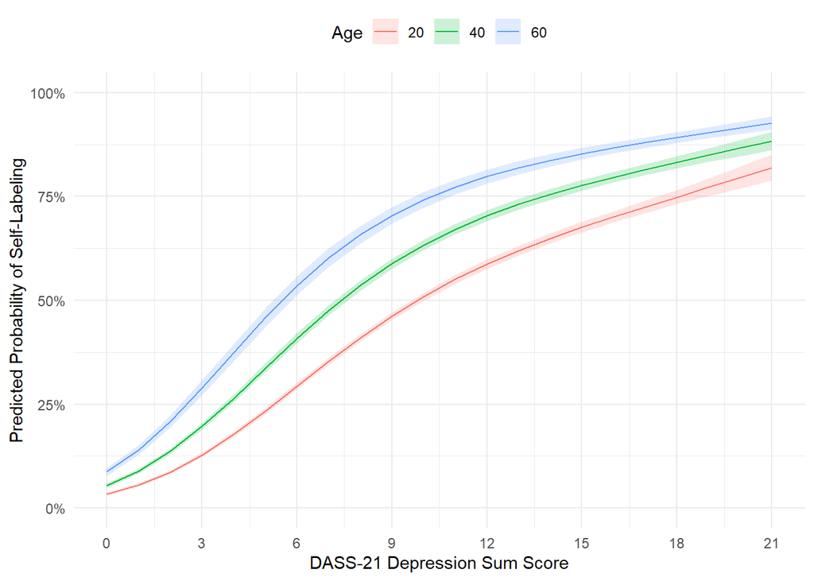

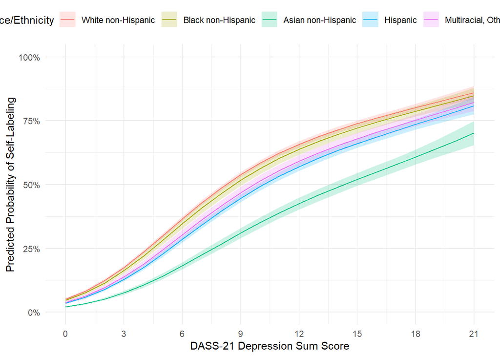

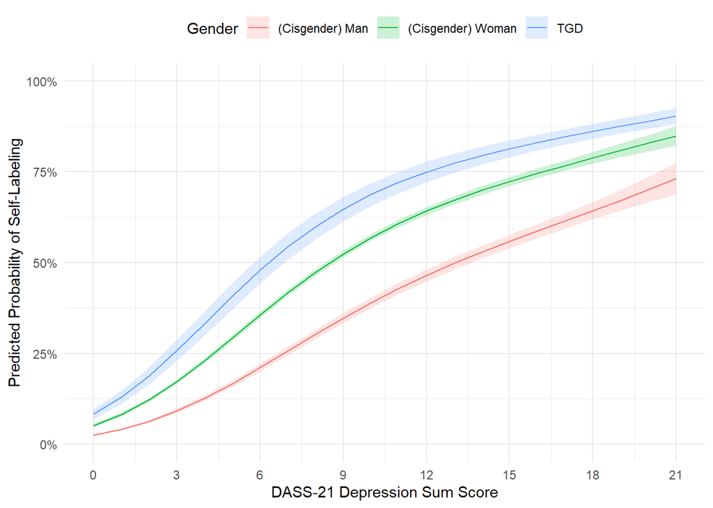

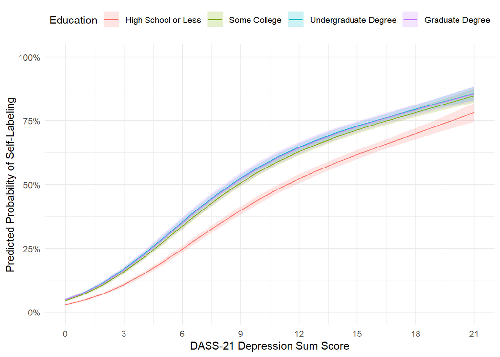

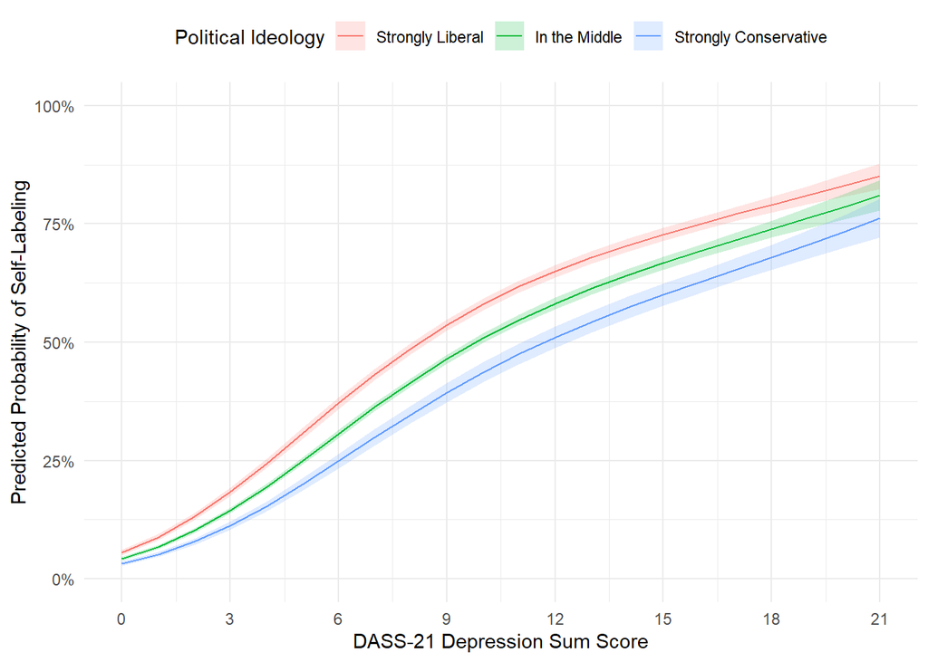

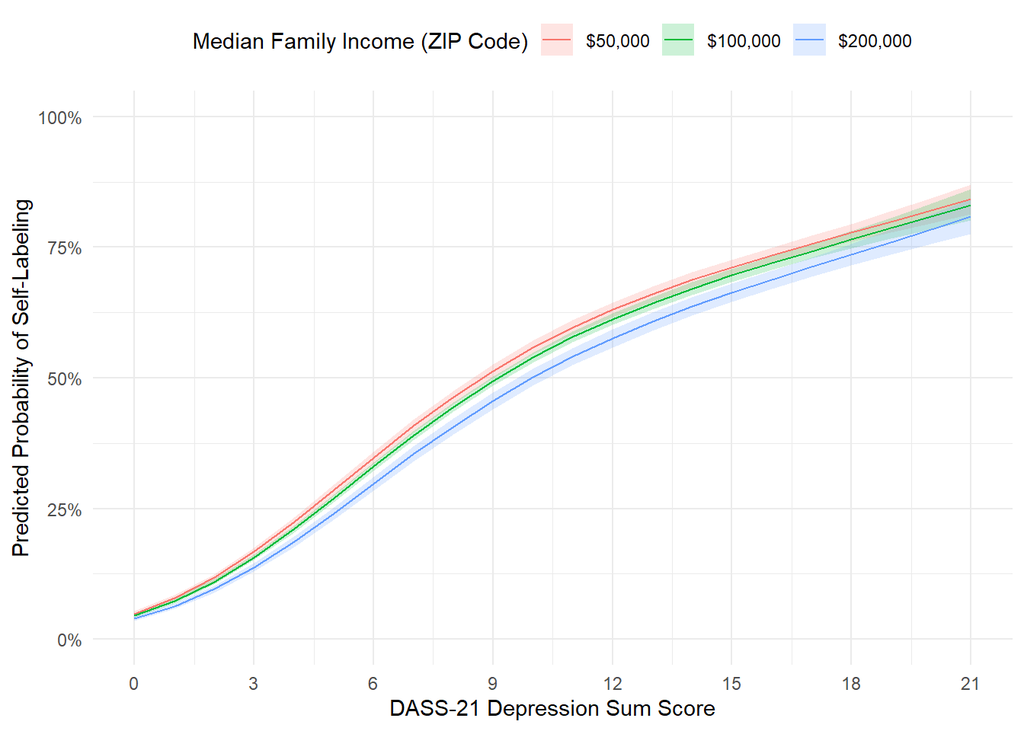

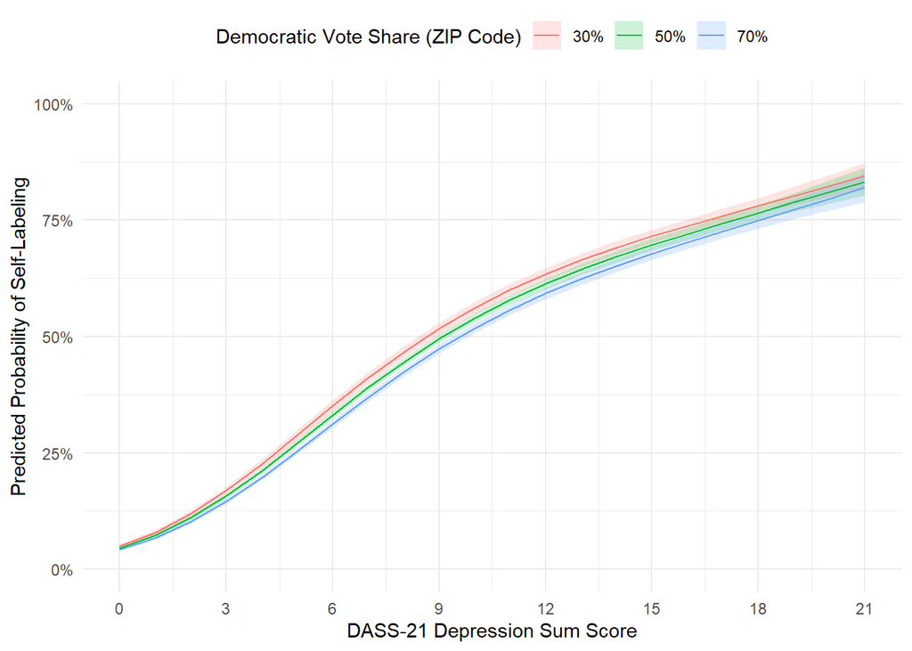

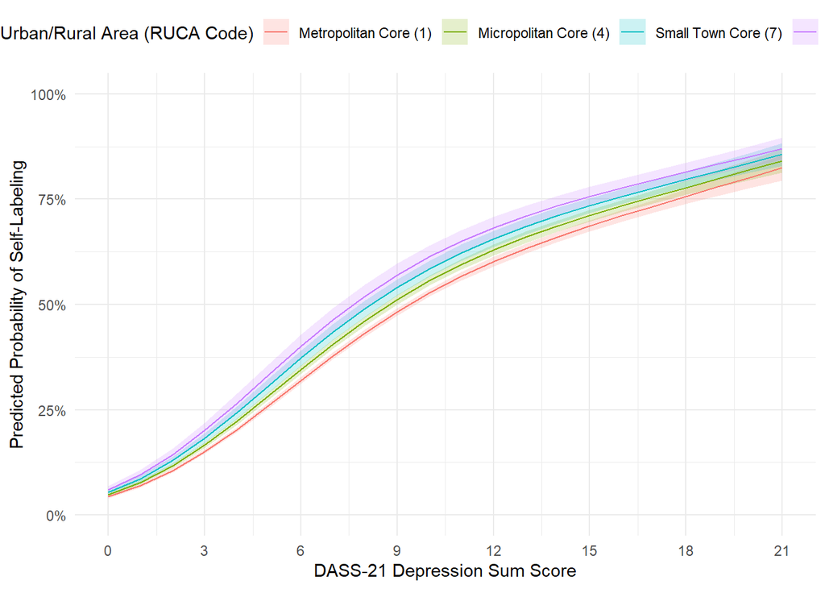

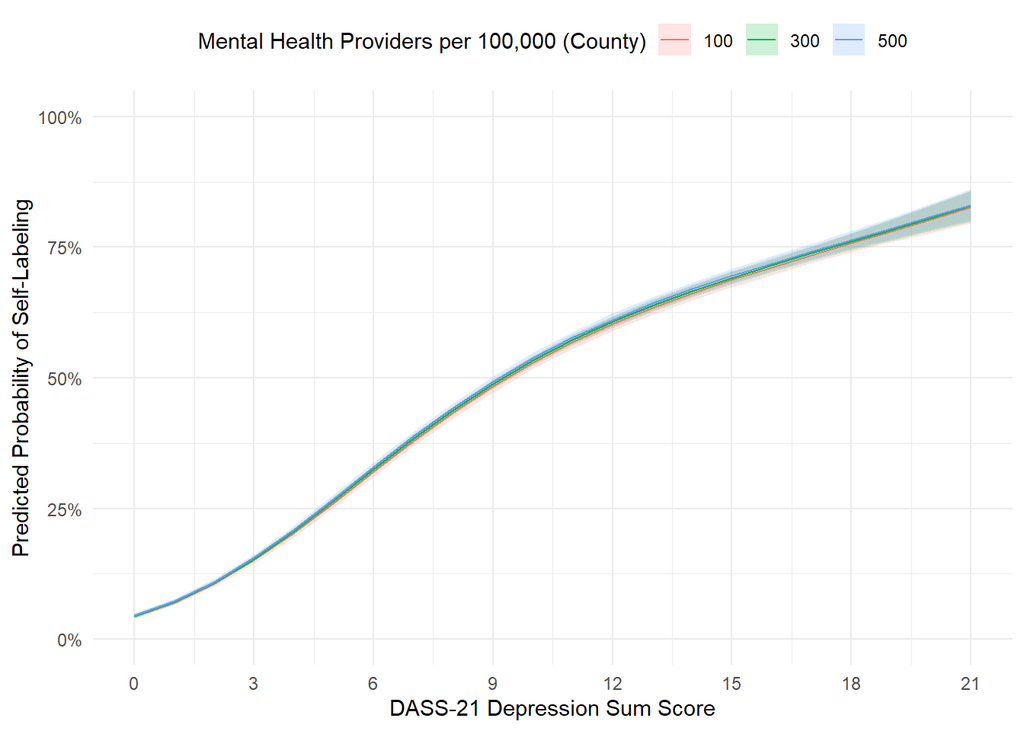

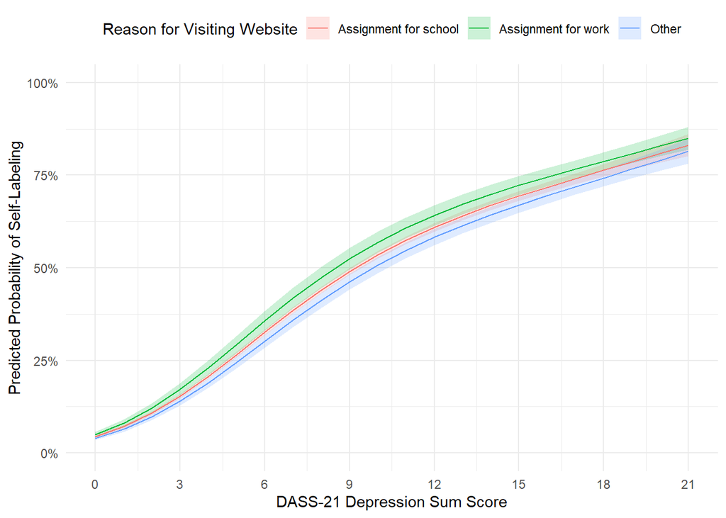

```r
# Visualized
iwalk(
  secondary,
  ~ label_groups(.x$curve, .y, covariate_values[[.y]], covariate_value_labels[[.y]]) %>%
    plot_curve_by(label = covariate_labels[[.y]]) %>%
    print()
)
```

We see significant differences in propensity to self-label, after controlling for depressive symptom severity, by all participant characteristics save for treatment access.

**Age:** This is probably the most surprising effect, as it cuts against what people assume to be true about “young people these days.” In fact, by the raw numbers, young people do self-label (slightly) more than older adults in this sample. However, they are also significantly more depressed. Once you adjust for depressive symptoms, younger people are less likely to self-label. Even this was surprising to me, since we know that younger people tend to have a broader sense of “what counts” as depression. But no matter how you slice it (see `Age Investigation.Rmd`) - controlling for referral source, looking within younger or older age brackets, etc. - this effect holds up. In fact, I examined this effect in an independent sample of ~4,000 adults 18-29 recruited on CloudResearch, and the effect replicates exactly. We will have to think this through. My first thought is labels are sticky and can accumulate over the course of one’s life; if someone identifies as “struggling with depression” at one point, they may continue to think of themselves that way even if their symptoms have improved in the future. Thus, while our sample’s 20-year-olds may be more likely to self-identify as having depression than our sample’s 40-year-olds were at their age, they are less likely to in this moment.

**Race/Ethnicity:** These are expected effects that follow known differences in concept breadth and stigma across cultures.

**Gender:** Likewise, these effects replicate those of previous studies - although it’s not immediately clear to me why these differences should be as strong as they are (particularly the difference between trans/gender-diverse adults and cisgender women).

**Education:** I’m not sure if this has been examined before. This feels intuitive to me, especially given the overlap with political ideology, below.

**Political Ideology:** This tracks expectations based on the relationship between political ideology and concept breadth, stigma.

**ZIP-Based Predictors:** Some of these run in interesting directions - for example, while more liberal participants are more likely to self-label, those in more liberal areas are less likely. This is mainly due to the confounding effect of race/ethnicity; White participants are more likely to self-label, and more likely to live in rural areas. These effects are examined further in `Robustness Checks/Geographic Indicator Investigation.Rmd`.

**Reason for Visiting Website:** This was my biggest concern for this study’s external validity. (Specifically: That effects exist in users visiting the website for school that don’t exist in other groups.) It’s reassuring that this variable has little to do with self-labeling (a significant effect here, but a very small one), and is not a moderator of our main concept creep analysis. This doesn’t mean that our sample of Project Implicit - Health visitors is perfectly representative of the broader U.S., but it does address one external validity concern.

# 4. Robustness Checks

Robustness checks are reported in the folder `Robustness Checks/`. They include:

- `Preregistered Models.Rmd`: Primary analyses using simple preregistered models
- `Complete Cases.Rmd`: Primary analyses using complete cases
- `Age Investigation.Rmd`: Robustness checks and a replication of age findings
- `Geographic Indicator Investigation.Rmd`: Robustness checks around ZIP-based secondary analyses